# Tarea1

Miguel Blanco y Franklin Alay

2023-10-31

La tabla de datos de que vamos a analizar en R será la de ocupaciones Cargamos la tabla de datos con read.csv, especificamos separador para que nos separe los datos correctamente

```r
ocupaciones <- read.csv("ocupaciones.csv", sep=";")
```

**1.**

En el dataframe “ocupaciones” la variable edad “age” es una variable cuantitativa discreta, ya que no presenta valores intermedios (no puedes tener 20.2 años) las variables “gender” y “occupation” serán del tipo categórica nominal, ya que representan categorias o grupos que no tienen un orden inherente. Al ser age la unica variable cuantitativa del df, vamos a calcular algunos parametros como su media, mediana máximo y mínimo su varianza y su desviacion estándar

```r
min(ocupaciones$age)
```

```
## [1] 7
```

```r
max(ocupaciones$age)
```

```
## [1] 73
```

```r
mean(ocupaciones$age)
```

```
## [1] 34.05196
```

```r
var(ocupaciones$age)
```

```
## [1] 148.6629
```

```r
sd(ocupaciones$age)
```

```
## [1] 12.19274
```

Vemos que las edades de los componentes del df ocupacuiones están entre 7 y 73 años, y la edad media es de 34 años. Presenta una desviación estándar de 12.19, lo que nos da una idea de la dispersión de los datos. Además de para obtener información de los datos, nos sirve para ver si alguno de los datos es erroneo, como podría ser una edad de 200 años o de -35 años.

**2.**

Ahora vamos a generar las tablas de frecuencias absolutas y relativas del df, y a partir de ahí calcular algunos parámetros que nos pueden ayudar a sacar conclusiones acerca de los datos.

```r
ocupaciones.abs <- table(ocupaciones$occupation)

ocupaciones.prop <- prop.table((ocupaciones.abs))

ocupaciones.abs
```

```
##
## administrator        artist        doctor      educator      engineer
##            79            28             7            95            67
## entertainment     executive    healthcare     homemaker        lawyer
##            18            32            16             7            12
##     librarian     marketing          none         other    programmer
##            51            26             9           105            66
##       retired      salesman     scientist       student    technician
##            14            12            31           196            27
##        writer
##            45
```

```r
ocupaciones.prop
```

```
##
## administrator        artist        doctor      educator      engineer
##   0.083775186   0.029692471   0.007423118   0.100742312   0.071049841
## entertainment     executive    healthcare     homemaker        lawyer
##   0.019088017   0.033934252   0.016967126   0.007423118   0.012725345
##     librarian     marketing          none         other    programmer
##   0.054082715   0.027571580   0.009544008   0.111346766   0.069989396
##       retired      salesman     scientist       student    technician
##   0.014846235   0.012725345   0.032873807   0.207847296   0.028632025
##        writer
##   0.047720042
```

Vamos a ver cuál es la ocupación más común (moda), para ello, buscamos la ocupacion que corresponde al valor máximo dentro de la tabla de frecuencias absolutas

```r
ocupaciones.abs[which.max(ocupaciones.abs)]
```

```
## student
##     196
```

Vemos que la ocupación más común es la de estudiante, que cuenta con 196 personas. Pero, ¿Existirá relación entre la ocupación que ejercen y la edad de la persona? Para resolver esta pregunta, vamos a dividir las edades por grupos utilizando la función cut, y sobre estos grupos vamos a realizar un análisis para ver si se producen alteraciones. Los grupo se generarán según la división en cuartiles de la variable edad.

```r
quantile(ocupaciones$age)
```

```
##   0%  25%  50%  75% 100%
##    7   25   31   43   73
```

```r
ocupaciones$age_group <- cut(ocupaciones$age, breaks = c (7, 25, 31, 43, 73), labels = c("7-25", "25-31", "31-43", "43-73"))
```

Los grupos de edad creados iran de 7 a 25, de 25 a 31, de 31 a 43 y de 43 a 73 años.

```r
table(ocupaciones$age_group)
```

```
##
##  7-25 25-31 31-43 43-73
##   271   201   242   228
```

Ahora usamos la funcion table con las columnas de ocupaciones y la recien creada age_group, que divide en grupos de edad

```r
abs.age.occupation <- table(ocupaciones$age_group, ocupaciones$occupation)

abs.age.occupation
```

```
##
##         administrator artist doctor educator engineer entertainment executive
##   7-25              9      9      0        4       13             9         2
##   25-31            17      7      2       15       13             2         8
##   31-43            25      8      1       30       25             5        10
##   43-73            28      4      4       46       16             2        12
##
##         healthcare homemaker lawyer librarian marketing none other programmer
##   7-25           1         2      1         2         2    4    24         14
##   25-31          4         1      4        15         6    2    26         23
##   31-43          3         3      3        15        12    2    28         19
##   43-73          8         1      4        19         6    1    27         10
##
##         retired salesman scientist student technician writer
##   7-25        0        3         3     152          8      9
##   25-31       0        2         7      32          6      9
##   31-43       0        4        17      11          8     13
##   43-73      14        3         4       0          5     14
```

Vamos a usar prop.table con para ver a qué grupo de edad pertenecen las personas que se dedican a cada ocupación

```r
prop.occupation_age <- prop.table(abs.age.occupation, margin = 2)

prop.occupation_age
```

```
##
##         administrator     artist     doctor   educator   engineer entertainment
##   7-25     0.11392405 0.32142857 0.00000000 0.04210526 0.19402985    0.50000000
##   25-31    0.21518987 0.25000000 0.28571429 0.15789474 0.19402985    0.11111111
##   31-43    0.31645570 0.28571429 0.14285714 0.31578947 0.37313433    0.27777778
##   43-73    0.35443038 0.14285714 0.57142857 0.48421053 0.23880597    0.11111111
##
##          executive healthcare  homemaker     lawyer  librarian  marketing
##   7-25  0.06250000 0.06250000 0.28571429 0.08333333 0.03921569 0.07692308
##   25-31 0.25000000 0.25000000 0.14285714 0.33333333 0.29411765 0.23076923
##   31-43 0.31250000 0.18750000 0.42857143 0.25000000 0.29411765 0.46153846
##   43-73 0.37500000 0.50000000 0.14285714 0.33333333 0.37254902 0.23076923
##
##               none      other programmer    retired   salesman  scientist
##   7-25  0.44444444 0.22857143 0.21212121 0.00000000 0.25000000 0.09677419
##   25-31 0.22222222 0.24761905 0.34848485 0.00000000 0.16666667 0.22580645
##   31-43 0.22222222 0.26666667 0.28787879 0.00000000 0.33333333 0.54838710
##   43-73 0.11111111 0.25714286 0.15151515 1.00000000 0.25000000 0.12903226
##
##            student technician     writer
##   7-25  0.77948718 0.29629630 0.20000000
##   25-31 0.16410256 0.22222222 0.20000000
##   31-43 0.05641026 0.29629630 0.28888889
##   43-73 0.00000000 0.18518519 0.31111111
```

Para una mejor comprensión de los datos anteriores, vamos a representar gráficamente. Para ello, vamos a extraer algunas de las ocupaciones de la tabla anterior, y las vamos a representar en un barplot, así veremos si los grupos de edad que desempeñan más una profesión varían según la profesión que sean. En este caso lo haremos con los estudiantes, los ingenieros y los administradores

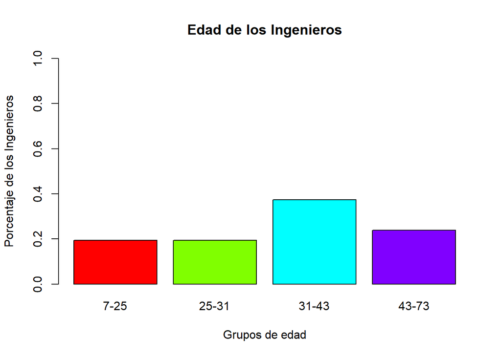

```r
#Ahora vamos a hacer lo mimso con otras ocupaciones, para ver si se produce un cambio en las edades que las desempeñan

#INGENIEROS

#Extraemos del df original a los que tienen como ocupacion engineer

FR.engineer <- ocupaciones[ocupaciones$occupation == "engineer",]

#calculamos la frecuencia absoluta por grupo de edad

FR.engineer <- table(FR.engineer$age_group)

#Calculamos la frecuencia relativa

FR.engineer <- prop.table(FR.engineer)

#Representamos graficamente

barplot(FR.engineer,
        col = rainbow(length(rownames(FR.engineer))),
        main = "Edad de los Ingenieros",
        xlab = "Grupos de edad",
        ylab = "Porcentaje de los Ingenieros",
        ylim = c(0,1))
```

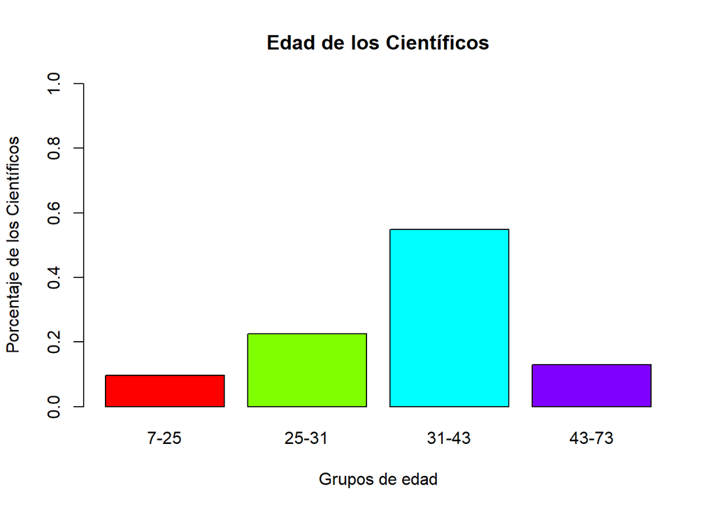

```r
#Repetimos el proceso con otras ocupaciones


#CIENTIFICOS
FR.cnt <- ocupaciones[ocupaciones$occupation == "scientist", ]

FR.cnt <- table(FR.cnt$age_group)

FR.cnt <- prop.table(FR.cnt)


barplot(FR.cnt,
        col = rainbow(length(rownames(FR.cnt))),
        main = "Edad de los Científicos",
        xlab = "Grupos de edad",
        ylab = "Porcentaje de los Científicos",
        ylim = c(0,1))
```

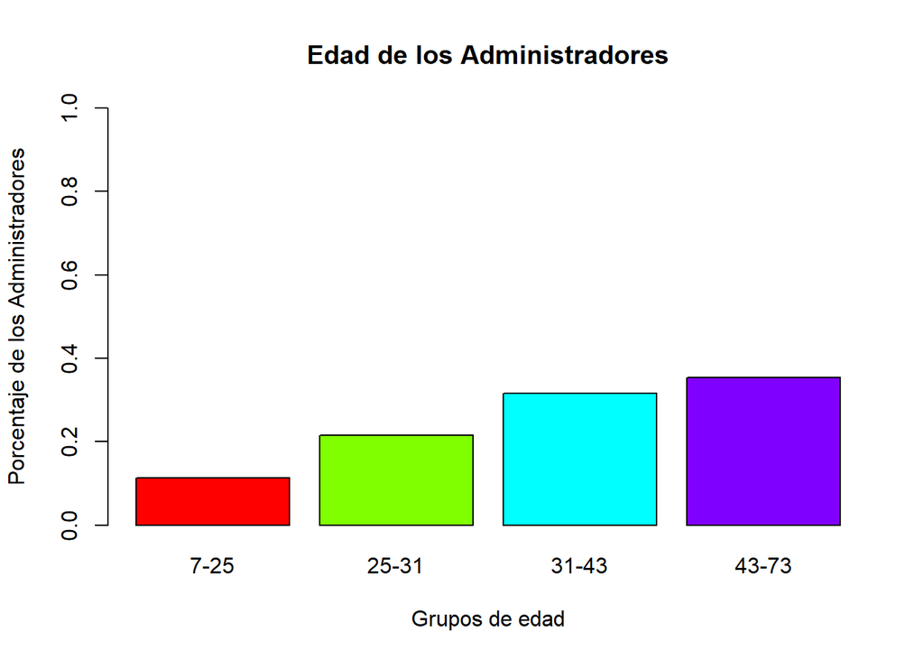

```r
#ADMINISTRADOR

FR.admn <- ocupaciones[ocupaciones$occupation == "administrator", ]

FR.admn <- table(FR.admn$age_group)

FR.admn <- prop.table(FR.admn)


barplot(FR.admn,
        col = rainbow(length(rownames(FR.admn))),
        main = "Edad de los Administradores",
        xlab = "Grupos de edad",
        ylab = "Porcentaje de los Administradores",
        ylim = c(0,1))
```

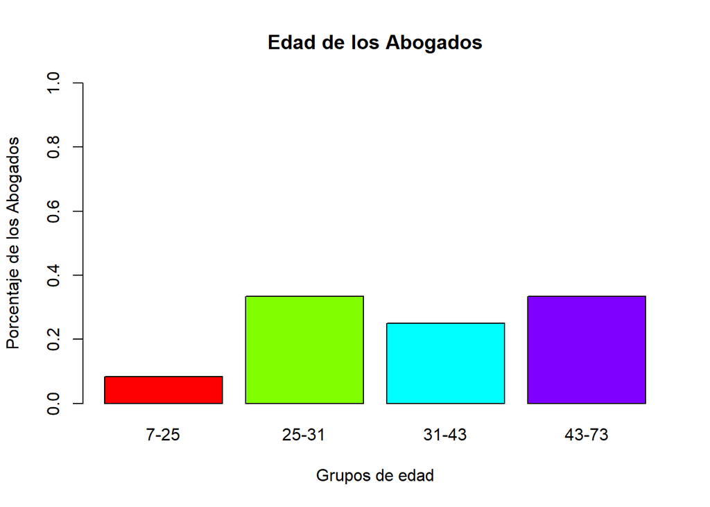

```r
#ABOGADOS

FR.ab <- ocupaciones[ocupaciones$occupation == "lawyer", ]

FR.ab <- table(FR.ab$age_group)

FR.ab <- prop.table(FR.ab)


barplot(FR.ab,
        col = rainbow(length(rownames(FR.ab))),
        main = "Edad de los Abogados",
        xlab = "Grupos de edad",
        ylab = "Porcentaje de los Abogados",
        ylim = c(0,1))
```

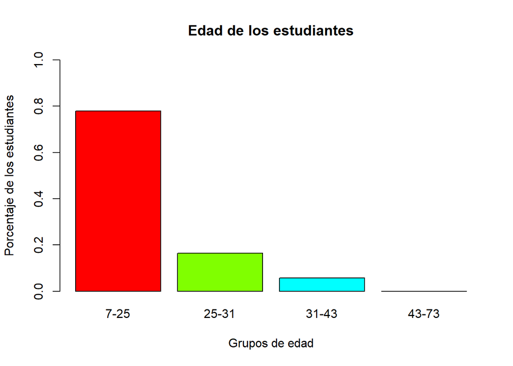

```r
#ESTUDIANTES

FR.student <- ocupaciones[ocupaciones$occupation =="student", ]

FR.student <- table(FR.student$age_group)

FR.student <- prop.table(FR.student)

barplot(FR.student,
        col = rainbow(length(rownames(FR.student))),
        main = "Edad de los estudiantes",
        xlab = "Grupos de edad",
        ylab = "Porcentaje de los estudiantes",
        ylim = c(0,1))
```

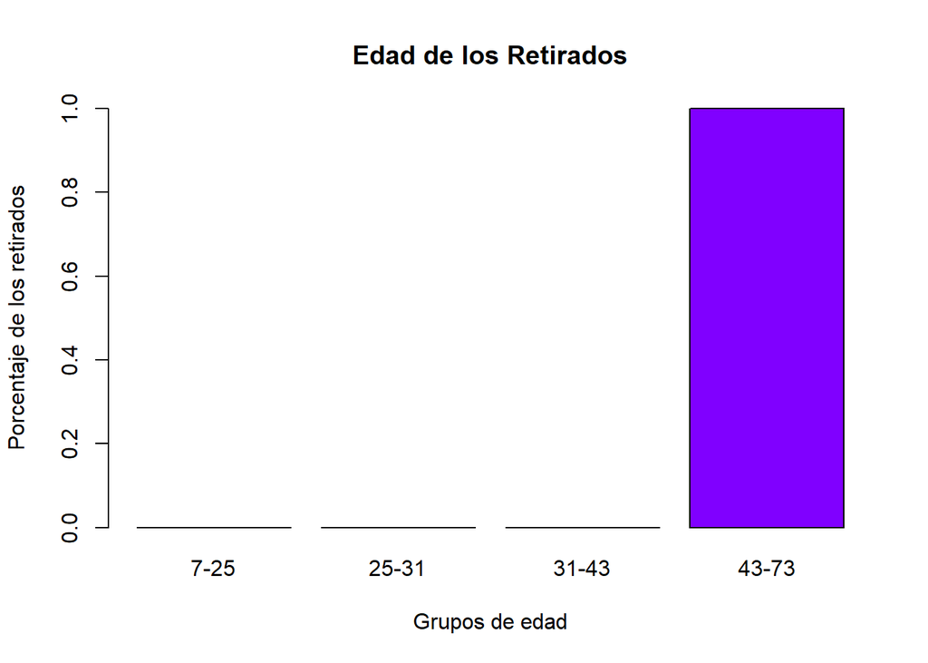

```r
#RETIRADOS

FR.ret <- ocupaciones[ocupaciones$occupation =="retired", ]

FR.ret <- table(FR.ret$age_group)

FR.ret <- prop.table(FR.ret)

barplot(FR.ret,
        col = rainbow(length(rownames(FR.ret))),
        main = "Edad de los Retirados",
        xlab = "Grupos de edad",
        ylab = "Porcentaje de los retirados",
        ylim = c(0,1))
```

Como podemos ver y era de esperar, se observa una clara diferencia en las personas que desempeñan las ocupaciones de estudiante y retirado, siendo la de estudiante claramente desempeñada en su mayoría por personas pertenecientes al grupo más joven, mientras que la de retirado esta desempeñada por los pertenecientes al grupo más mayor. Si miramos las otras ocupaciones representadas, vemos que se distribuyen de manera mucho más equitativa entre los distintos grupos, siendo algo menor en el grupo más joven debido a que muchos de sus integrantes no se encuentran aún en edad laboral. En cuanto a diferencias entre las ocupaciones, vemos que en las ocupaciones de ingenieros y científicos el grupo de 43-73 años representa un porcentaje menor que en las profesiones de administrador y abogado. Esto puede deberse, quizás, a que las profesiones de ingeniero y científico son más nuevas y futuristas, mientras que las profesiones de administrador y abogado son más tradicionales y requieren más de la experiencia.

Para esto vamos a crear un vector con todos los grupos de edad y luego un bucle for que recorra este vector y para cada grupo de edad extraiga su fila, a la vez de esto eliminamos los valores 0, para que no entorpezcan en la visualización del pie chart y vamos acumulando en una lista que hemos creado previamente. Luego accedemos a cada elemento de la lista y lo representamos en un pie chart.

```r
grupos <- c("7-25", "25-31", "31-43", "43-73")


groups_list <- list()

for (edades in grupos) {

  group_row <- prop.occupation_age[edades, ]
  group_row_no0 <- group_row[group_row!= 0]
  groups_list[[edades]] <- group_row_no0

}

groups_list
```

```
## $`7-25`
## administrator        artist      educator      engineer entertainment
##    0.11392405    0.32142857    0.04210526    0.19402985    0.50000000
##     executive    healthcare     homemaker        lawyer     librarian
##    0.06250000    0.06250000    0.28571429    0.08333333    0.03921569
##     marketing          none         other    programmer      salesman
##    0.07692308    0.44444444    0.22857143    0.21212121    0.25000000
##     scientist       student    technician        writer
##    0.09677419    0.77948718    0.29629630    0.20000000
##
## $`25-31`
## administrator        artist        doctor      educator      engineer
##     0.2151899     0.2500000     0.2857143     0.1578947     0.1940299
## entertainment     executive    healthcare     homemaker        lawyer
##     0.1111111     0.2500000     0.2500000     0.1428571     0.3333333
##     librarian     marketing          none         other    programmer
##     0.2941176     0.2307692     0.2222222     0.2476190     0.3484848
##      salesman     scientist       student    technician        writer
##     0.1666667     0.2258065     0.1641026     0.2222222     0.2000000
##
## $`31-43`
## administrator        artist        doctor      educator      engineer
##    0.31645570    0.28571429    0.14285714    0.31578947    0.37313433
## entertainment     executive    healthcare     homemaker        lawyer
##    0.27777778    0.31250000    0.18750000    0.42857143    0.25000000
##     librarian     marketing          none         other    programmer
##    0.29411765    0.46153846    0.22222222    0.26666667    0.28787879
##      salesman     scientist       student    technician        writer
##    0.33333333    0.54838710    0.05641026    0.29629630    0.28888889
##
## $`43-73`
## administrator        artist        doctor      educator      engineer
##     0.3544304     0.1428571     0.5714286     0.4842105     0.2388060
## entertainment     executive    healthcare     homemaker        lawyer
##     0.1111111     0.3750000     0.5000000     0.1428571     0.3333333
##     librarian     marketing          none         other    programmer
##     0.3725490     0.2307692     0.1111111     0.2571429     0.1515152
##       retired      salesman     scientist    technician        writer
##     1.0000000     0.2500000     0.1290323     0.1851852     0.3111111
```

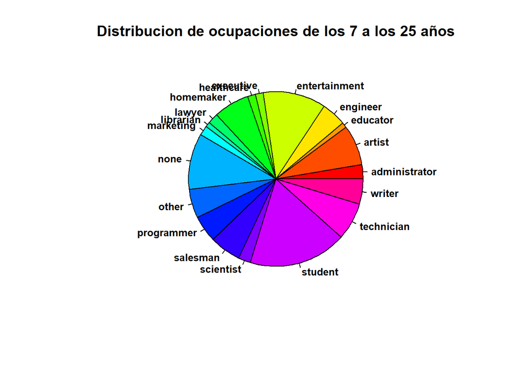

```r
pie(groups_list[[1]],
    main = "Distribucion de ocupaciones de los 7 a los 25 años",
    col = rainbow(length(group_row_no0)),
    font = 2,
    cex = 0.8)
```

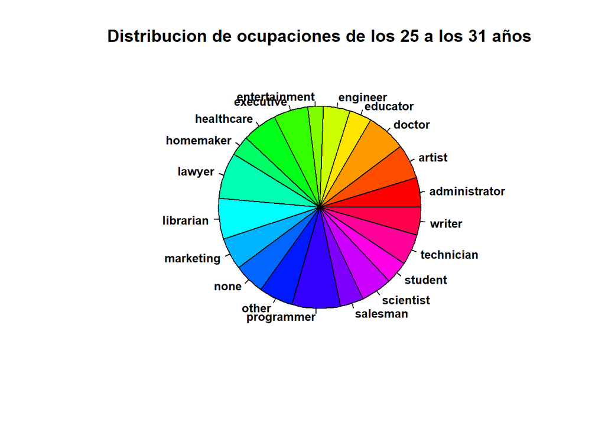

```r
#25-31


pie(groups_list[[2]],
    main = "Distribucion de ocupaciones de los 25 a los 31 años",
    col = rainbow(length(groups_list[[2]])),
    font = 2,
    cex = 0.8,)
```

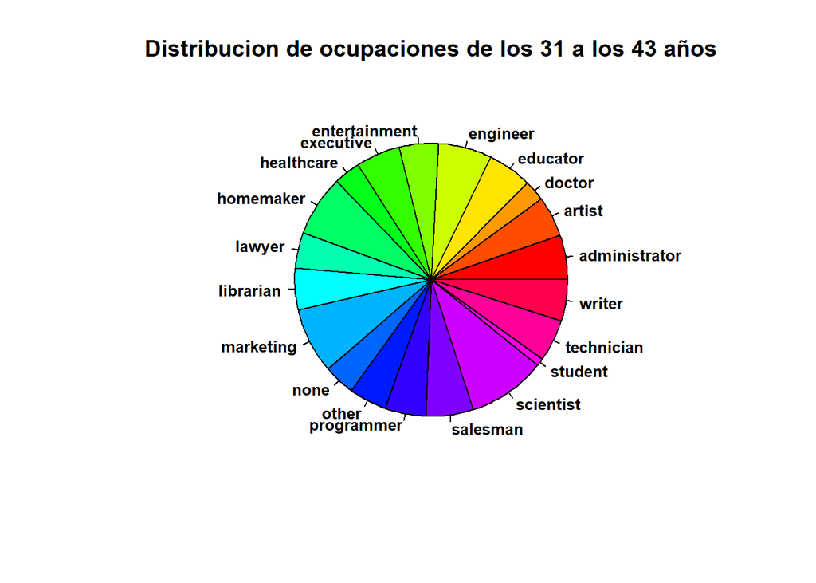

```r
#31-43

pie(groups_list[[3]],
    main = "Distribucion de ocupaciones de los 31 a los 43 años",
    col = rainbow(length(groups_list[[3]])),
    font = 2,
    cex = 0.8,)
```

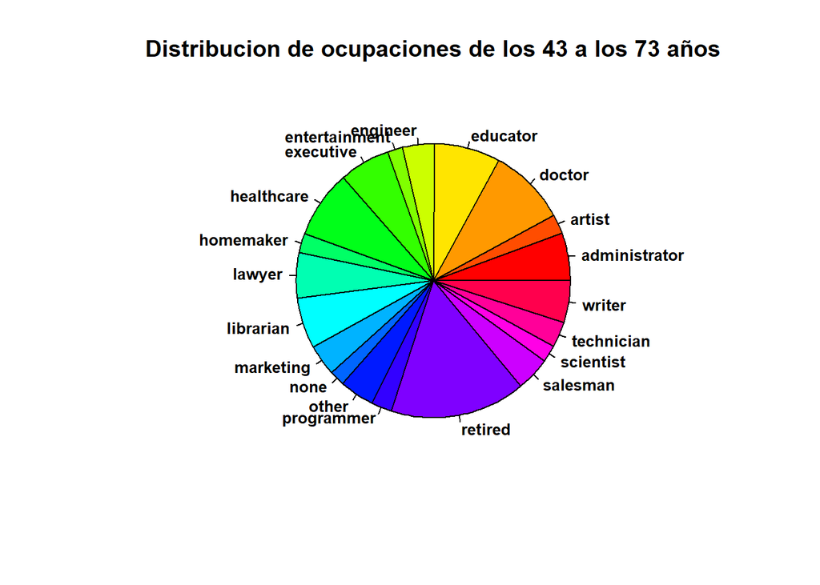

```r
#43-73

pie(groups_list[[4]],
    main = "Distribucion de ocupaciones de los 43 a los 73 años",
    col = rainbow(length(groups_list[[4]])),
    font = 2,
    cex = 0.8,)
```